[figure not shown]

# Basic spatial operations in Geo Dataframes

We will review some important formatting processes for geodataframes. As usual, let's do this:

1. Create a repository named: **geodfprepro**.
2. Clone that repo to a local folder in your computer.
3. In that local folder in your computer, create a folder named **maps** and **data**.
4. Put the **brazilMaps_5641.gpkg** file that contains the three maps prepared last class into the map folder.
5. Download the shapefile of "Brazil - Subnational Administrative Boundaries" from [here](https://data.humdata.org/dataset/cod-ab-bra) and save it in the maps folder (you need to unzip the file).
6. Download a **CSV** file with information on the airports in Brazil from this [website](https://data.humdata.org/dataset/ourairports-bra), I will save it in my **data** folder:
7. Commit and push.

```python
import os


import geopandas as gpd
from  fiona import listlayers

#maps
argentinaMaps='https://github.com/Romina300/simpleplot/raw/main/maps/argentina22171/argentinaMaps22171.gpkg'

#layers in maps
listlayers(argentinaMaps)
```

```
['country', 'cities', 'rivers']
```

Retrieving each map (layer):

```python
argentina=gpd.read_file(argentinaMaps,layer='country')
argentina_cities=gpd.read_file(argentinaMaps,layer='cities')
argentina_rivers=gpd.read_file(argentinaMaps,layer='rivers')
```

We know they share the same CRS:

```python
argentina.crs.to_epsg()==argentina_cities.crs.to_epsg()==argentina_rivers.crs.to_epsg()
```

```
True
```

We also remember that having the same CRS allows one plot with several layers of maps:

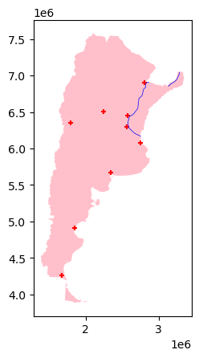

```python
# plotting tinee que tner el mismo cr para que cada layer salga encima de otro ene la psoicion correcta
base = argentina.plot(facecolor="pink")
argentina_rivers.plot(edgecolor='blue', linewidth=0.5,ax=base)
argentina_cities.plot(marker='+', color='red', markersize=15,ax=base)
```

Now, let's see some important **spatial operations**:

1. Formatting Projection
   - Projecting Geoseries
   - Projecting Naive Geodata
   - Projecting long/lat
2. Combining GeoDF rows
   - Dissolving
   - Unary union
3. Creating Spatial Points
   - Creating a convex hull
4. Checking Validity

## Formating Geoseries projections

```python
argentina
```

|  | COUNTRY | geometry |
| --- | --- | --- |
| 0 | Argentina | MULTIPOLYGON (((1588143.249 5963164.249, 15912... |

Sometime, you just need the border (lines):

```python
argentina.boundary #por eso es multistring porque estoy pidiendo que gurade el borde del poligono
#me da un valor es como un dao el excel, es como que me da un valor dame la media y me da 3.5
#son diefentes estrcuturas de datos y por ello aplicaremos cierto tipo de funciones dependiedno de la estrcutura
```

```
0    MULTILINESTRING ((1588143.249 5963164.249, 159...
dtype: geometry
```

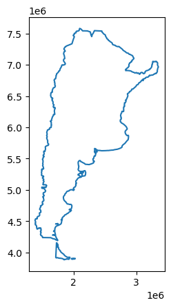

```python
# This is just the borderline
argentina.boundary.plot()
```

Always check the data type:

```python
# does 'boundary' return a GDF?
type(argentina.boundary)
```

```
geopandas.geoseries.GeoSeries
```

**Some operations** in geopandas **require GDF or GS**. If you need a GDF instead of a GS:

```python
# converting into GDF
argentina.boundary.to_frame() #aqui lo he convertido en una tabla geodataframe
#esto es un gdf a partir de una geoseries
#le puedo decri a pyhton datos cual es la columna que tiene datos geometricos indepedneitemente de su nombre 'geometrías'
#por si acaso la geometria es 'geometrías'
#me asegruo de decirle cual es la geometria
```

|  | 0 |
| --- | --- |
| 0 | MULTILINESTRING ((1588143.249 5963164.249, 159... |

Notice **you get a very simple GDF**, and you may want to add some information:

```python
# conversion
argentina_border=argentina.boundary.to_frame()

# new column (optional)
argentina_border['name']='Argentina'

# renaming the geometry column
argentina_border.rename(columns={0:'geometry'},inplace=True)

#setting the geometry (the name is not enough)
argentina_border = argentina_border.set_geometry("geometry")

# verifying:
argentina_border.crs
```

```
<Projected CRS: EPSG:22171>
Name: POSGAR 98 / Argentina 1
Axis Info [cartesian]:
- X[north]: Northing (metre)
- Y[east]: Easting (metre)
Area of Use:
- name: Argentina - west of 70°30'W.
- bounds: (-73.59, -52.0, -70.5, -36.16)
Coordinate Operation:
- name: Argentina zone 1
- method: Transverse Mercator
Datum: Posiciones Geodesicas Argentinas 1998
- Ellipsoid: GRS 1980
- Prime Meridian: Greenwich
```

You see you *multistring*:

```python
argentina_border #en la tarea tine que parecere tal cual asi geometry name y multistring
```

|  | geometry | name |
| --- | --- | --- |
| 0 | MULTILINESTRING ((1588143.249 5963164.249, 159... | Argentina |

### Exercise 1

1. Check if your country is a polygon or multipolygon. 2. Recover just the boundaries of that country. 3. Turn the boundary into a GDF.

## Lacking CRS information

Reprojecting seems a simple process, but you might find some interesting cases. Let's **read the maps on *states* and *municipalities***: y ambos son poligonos

```python
argentina_states=gpd.read_file(os.path.join("maps","arg_adm_unhcr2017_SHP","arg_admbnda_adm1_unhcr2017.shp"))
argentina_municipalities=gpd.read_file(os.path.join("maps","arg_adm_unhcr2017_SHP","arg_admbnda_adm2_unhcr2017.shp"))
```

Notice this:

```python
argentina_states.crs, argentina_municipalities.crs
```

```
(<Projected CRS: EPSG:3857>
 Name: WGS 84 / Pseudo-Mercator
 Axis Info [cartesian]:
 - X[east]: Easting (metre)
 - Y[north]: Northing (metre)
 Area of Use:
 - name: World between 85.06°S and 85.06°N.
 - bounds: (-180.0, -85.06, 180.0, 85.06)
 Coordinate Operation:
 - name: Popular Visualisation Pseudo-Mercator
 - method: Popular Visualisation Pseudo Mercator
 Datum: World Geodetic System 1984 ensemble
 - Ellipsoid: WGS 84
 - Prime Meridian: Greenwich,
 <Geographic 2D CRS: EPSG:4326>
 Name: WGS 84
 Axis Info [ellipsoidal]:
 - Lat[north]: Geodetic latitude (degree)
 - Lon[east]: Geodetic longitude (degree)
 Area of Use:
 - name: World.
 - bounds: (-180.0, -90.0, 180.0, 90.0)
 Datum: World Geodetic System 1984 ensemble
 - Ellipsoid: WGS 84
 - Prime Meridian: Greenwich)
```

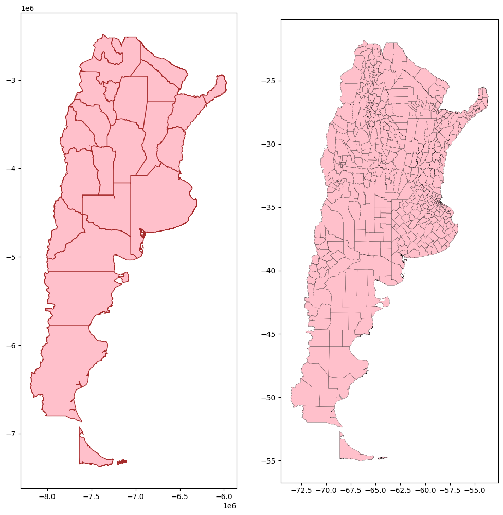

```python
import matplotlib.pyplot as plt

fig, (ax1, ax2) = plt.subplots(ncols=2, sharex=False, sharey=False, figsize=(12,12))

argentina_states.plot(ax=ax1, facecolor='pink', edgecolor='brown')
argentina_municipalities.plot(ax=ax2, facecolor='pink', edgecolor='black',linewidth=0.2)
```

```python
argentina_states.to_crs(22171)
```

|  | ADM0_ES | ADM0_PCODE | ADM1_ES | ADM1_PCODE | geometry |
| --- | --- | --- | --- | --- | --- |
| 0 | Argentina | AR | Buenos Aires | AR006 | MULTIPOLYGON Z (((2335919.444 5475450.748 0.00... |
| 1 | Argentina | AR | Catamarca | AR010 | POLYGON Z ((1906189.076 7204695.456 0.000, 191... |
| 2 | Argentina | AR | Chaco | AR022 | POLYGON Z ((2494292.791 7296258.081 0.000, 249... |
| 3 | Argentina | AR | Chubut | AR026 | MULTIPOLYGON Z (((1916196.919 4975824.860 0.00... |
| 4 | Argentina | AR | Ciudad de Buenos Aires | AR002 | POLYGON Z ((2747577.276 6094399.410 0.000, 274... |
| 5 | Argentina | AR | Córdoba | AR014 | POLYGON Z ((2288373.932 6695803.079 0.000, 228... |
| 6 | Argentina | AR | Corrientes | AR018 | MULTIPOLYGON Z (((3004612.053 6855238.635 0.00... |
| 7 | Argentina | AR | Entre Ríos | AR030 | POLYGON Z ((2798505.825 6586816.825 0.000, 279... |
| 8 | Argentina | AR | Formosa | AR034 | POLYGON Z ((2497424.367 7484757.793 0.000, 249... |
| 9 | Argentina | AR | Jujuy | AR038 | POLYGON Z ((2098377.586 7581146.835 0.000, 210... |
| 10 | Argentina | AR | La Pampa | AR042 | POLYGON Z ((2188602.680 6101304.588 0.000, 219... |
| 11 | Argentina | AR | La Rioja | AR046 | POLYGON Z ((1842905.218 6918621.830 0.000, 184... |
| 12 | Argentina | AR | Mendoza | AR050 | POLYGON Z ((1771643.879 6456186.096 0.000, 177... |
| 13 | Argentina | AR | Misiones | AR054 | MULTIPOLYGON Z (((3095005.586 6872963.019 0.00... |
| 14 | Argentina | AR | Neuquén | AR058 | POLYGON Z ((1644565.805 5998409.218 0.000, 164... |
| 15 | Argentina | AR | Río negro | AR062 | MULTIPOLYGON Z (((2110903.688 5460168.313 0.00... |
| 16 | Argentina | AR | Salta | AR066 | POLYGON Z ((2451820.395 7539541.582 0.000, 245... |
| 17 | Argentina | AR | San Juan | AR070 | POLYGON Z ((1734160.435 6855329.798 0.000, 173... |
| 18 | Argentina | AR | San Luis | AR074 | POLYGON Z ((1968211.713 6465395.769 0.000, 196... |
| 19 | Argentina | AR | Santa Cruz | AR078 | MULTIPOLYGON Z (((1681041.738 4336736.817 0.00... |
| 20 | Argentina | AR | Santa Fe | AR082 | POLYGON Z ((2663631.362 6846895.383 0.000, 270... |
| 21 | Argentina | AR | Santiago del Estero | AR086 | POLYGON Z ((2502694.378 7125547.160 0.000, 250... |
| 22 | Argentina | AR | Tierra del Fuego | AR094 | MULTIPOLYGON Z (((1848191.934 3884066.663 0.00... |
| 23 | Argentina | AR | Tucumán | AR090 | POLYGON Z ((2165451.970 7101554.297 0.000, 216... |

```python
argentina_states.geometry.head()
```

```
0    MULTIPOLYGON Z (((-6918884.037 -4931769.351 0....
1    POLYGON Z ((-7566501.154 -2903626.584 0.000, -...
2    POLYGON Z ((-6929548.312 -2770568.731 0.000, -...
3    MULTIPOLYGON Z (((-7424844.932 -5660565.812 0....
4    POLYGON Z ((-6507173.600 -4100891.637 0.000, -...
Name: geometry, dtype: geometry
```

```python
argentina_states.crs = "EPSG:4326"
argentina_municipalities.crs = "EPSG:4326"
```

Now, we can reproject:

```python
argentina_states=argentina_states.to_crs(22171)
argentina_municipalities=argentina_municipalities.to_crs(22171)
```

### Exercise 2

1. Look for sub administrative divisions of your country obligatorio, pero si tienen los crs ya no hay nada mas que hacer es opcional encontrar un pais que no lo tenga y ponerle nombre =ESPG=5346 2. Check all the CRSs of those divisions 3. If you find one CRS is missing, fill the CRS with the right projection.

## Projecting Lat/Lon Points

You will get Lines and Polygons as maps for sure, but that may not be the case with points. These points came as a CSV file:

```python
import pandas as pd
infomuseos=pd.read_csv(os.path.join("data","museos_datosabiertos.csv"))

# see

infomuseos
#EL QUE TENGA CORRDENADAS NO LO HAVE UN OBEJTO ESPACIAL
#Es importante porque en algun momneto mr van a dar coordenadas y tengo que saber como convetir
```

|  | Cod_Loc | IdProvincia | IdDepartamento | Observaciones | categoria | subcategoria | provincia | localidad | nombre | direccion | ... | Mail | Web | Latitud | Longitud | TipoLatitudLongitud | Info_adicional | fuente | jurisdiccion | año_inauguracion | actualizacion |
| --- | --- | --- | --- | --- | --- | --- | --- | --- | --- | --- | --- | --- | --- | --- | --- | --- | --- | --- | --- | --- | --- |
| 0 | 6588100 | 6 | 6588 | NaN | Espacios de Exhibición Patrimonial | Museos | Buenos Aires | 9 de Julio | Archivo Y Museo Histórico Gral. Julio De Vedia | Libertad 1191 | ... | archivoymuseo@yahoo.com.ar | www.portaldel9.com.ar | -35.441762 | -60.887598 | Localización precisa | NaN | DNPyM | Municipal | 1920.0 | 2017 |
| 1 | 6077010 | 6 | 6077 | NaN | Espacios de Exhibición Patrimonial | Museos | Buenos Aires | Arrecifes | Museo Y Archivo Histórico De Arrecifes | Gerardo Risso y España | ... | museoarrecifes@hotmail.com | NaN | -34.066970 | -60.102555 | Localización precisa | NaN | DNPyM | Municipal | 1972.0 | 2017 |
| 2 | 6035010 | 6 | 6035 | NaN | Espacios de Exhibición Patrimonial | Museos | Buenos Aires | Avellaneda | Museo Histórico-Sacro Hno. Rogelio Scortegagna | Calle 11 (Av. San Martín) Nº 830 | ... | NaN | NaN | -29.118024 | -59.654543 | Localización precisa | NaN | DNPyM | Municipal | NaN | 2017 |
| 3 | 6035010 | 6 | 6035 | NaN | Espacios de Exhibición Patrimonial | Museos | Buenos Aires | Avellaneda | Museo Municipal De Artes Plásticas De Avellaneda | Sarmiento 101, 1 º Piso | ... | NaN | NaN | -34.662110 | -58.363270 | Localización precisa | NaN | DNPyM | Municipal | 1956.0 | 2017 |
| 4 | 6049020 | 6 | 6049 | NaN | Espacios de Exhibición Patrimonial | Museos | Buenos Aires | Azul | Museo Etnográfico Y Archivo Histórico Enrique ... | Bartolomé J. Ronco 654 | ... | museoazul@yahoo.com | NaN | -36.781824 | -59.858636 | Localización precisa | NaN | DNPyM | Privada | 1949.0 | 2017 |
| ... | ... | ... | ... | ... | ... | ... | ... | ... | ... | ... | ... | ... | ... | ... | ... | ... | ... | ... | ... | ... | ... |
| 1177 | 90098040 | 90 | 90098 | NaN | Espacios de Exhibición Patrimonial | Museos | Tucumán | Tafí del Valle | Museo Histórico Y Arqueológico Jesuítico La Banda | La Banda S/N | ... | NaN | NaN | -26.852880 | -65.712622 | Localización precisa | NaN | DNPyM | NaN | NaN | 2017 |
| 1178 | 90105080 | 90 | 90105 | NaN | Espacios de Exhibición Patrimonial | Museos | Tucumán | Tafí Viejo | Mac-Museo Arqueológico El Cadillal | Centro Principal el Cadillal | ... | NaN | NaN | -26.683331 | -65.266670 | Localización precisa | NaN | DNPyM | Provincial | NaN | 2017 |
| 1179 | 90105080 | 90 | 90105 | NaN | Espacios de Exhibición Patrimonial | Museos | Tucumán | Tafí Viejo | Museo Ferroviario De Los Talleres De Tafí Viejo | Avda. Pte. Roque Sáenz Peña 234 | ... | NaN | NaN | -26.740733 | -65.263231 | Localización precisa | NaN | DNPyM | Privada | 1909.0 | 2017 |
| 1180 | 90105070 | 90 | 90105 | NaN | Espacios de Exhibición Patrimonial | Museos | Tucumán | Villa El Cadillal | Museo Arqueológico Dr. Ernesto Padilla | Ernesto Padilla S/N | ... | NaN | NaN | -21.937642 | -66.052043 | Localización precisa | NaN | DNPyM | Provincial | NaN | 2017 |
| 1181 | 90098040 | 90 | 90098 | NaN | Espacios de Exhibición Patrimonial | Museos | Tucumán | Tafí del Valle | Asentamientos De Menhires En Las Áreas Arqueol... | NaN | ... | NaN | www.enteculturaltucuman.gov.ar | -26.852880 | -65.712622 | Localización precisa | Lugar Histórico | CNMLH - Ente Cultural de Tucumán | Provincial | NaN | 2017 |

1182 rows × 24 columns

```python
# bye first row
infomuseos.drop(index=0,inplace=True)
infomuseos.reset_index(drop=True, inplace=True)

# keep the  columns needed
keep=['nombre','jurisdiccion','Latitud', 'Longitud','provincia','localidad']
infomuseos=infomuseos.loc[:,keep]
infomuseos.info()
```

```
<class 'pandas.core.frame.DataFrame'>
RangeIndex: 1180 entries, 0 to 1179
Data columns (total 6 columns):
 #   Column        Non-Null Count  Dtype
---  ------        --------------  -----
 0   nombre        1180 non-null   object
 1   jurisdiccion  1083 non-null   object
 2   Latitud       1180 non-null   float64
 3   Longitud      1180 non-null   float64
 4   provincia     1180 non-null   object
 5   localidad     1180 non-null   object
dtypes: float64(2), object(4)
memory usage: 55.4+ KB
```

```python
#numericCols=['Latitud', 'Longitud']
#infoairports[numericCols]=infoairports.loc[:,numericCols].apply(lambda x:pd.to_numeric(x))

# now
#infoairports.info()
```

[output not shown]

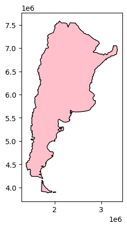

```python
# let's plot

mapabase = argentina.plot(color='pink', edgecolor='black') #unprojected

infomuseos.plot.scatter(x = 'Longitud', y = 'Latitud',ax=base)
```

We get it wrong because coordinates of both **do not match**. Let's try this:

1. Create a **GeoDataFrame with the points, keeping them unprojected**:

```python
museos=gpd.GeoDataFrame(data=infomuseos.copy(),
                 geometry=gpd.points_from_xy(infomuseos.Longitud,
                                             infomuseos.Latitud),
                 crs=4326)# the coordinates were in degrees - unprojected
#simepre q alg diga longitud latitud es q est a no protyecatdi
#e 5341 es la proyeccion del mapa de brasil
```

```python
museos
```

[output not shown]

1180 rows × 7 columns

museos

1. Reproject the GeoDataFrame:

```python
museos=museos.to_crs(22171)
```

Does it look better?

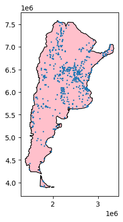

```python
# let's plot

base = argentina.plot(color='pink', edgecolor='black')
museos.plot(ax=base,markersize=1)
```

# Now we have a **spatial points**: wiii

```python
#remember:
type(museos), type(infomuseos)
```

```
(geopandas.geodataframe.GeoDataFrame, pandas.core.frame.DataFrame)
```

```python
museos['jurisdiccion'].value_counts() # this will not work: airports.type.value_counts()
#recomendacon es no ponerle type como nmbre de columna porque de por si type es una funcion q te indica el tipo de dato
```

```
jurisdiccion
Municipal                                                                           429
Privada                                                                             255
Provincial                                                                          167
Nacional                                                                            143
s/d                                                                                  32
Comunal                                                                              24
Privado                                                                              12
Mixta                                                                                 5
Provincial y Municipal                                                                3
Gobierno de la Ciudad                                                                 3
Mixta: Orden Franciscana y Municipalidad de San Fernando del Valle de Catamarca.      2
Mixta: Municipal / Privada                                                            1
Mixto Provincial y Privado                                                            1
Mixta-Privada/Municipal                                                               1
Mixta Provincial/Municipal                                                            1
Mixta: Privada/Municipal                                                              1
Mixta, Nacional y Municipal                                                           1
Mixta: Municipal/Privada                                                              1
Puerto                                                                                1
Name: count, dtype: int64
```

We may use that in the future. For now, just give the **type** column a different name.

```python
#airports.rename(columns={'type':'kind'},inplace=True)
```

Let's play with this:

```python
from folium import LayerControl


m = museos[museos.jurisdiccion=='Municipal'].explore(color="red",name="Municipal",show=False)
m = museos[museos.jurisdiccion=='Privada'].explore(m=m, color="blue",name="Privada",show=False)
m = museos[museos.jurisdiccion=='Provincial'].explore(m=m, color="black",name="Provincial",show=True)
m = museos[museos.jurisdiccion=='Nacional'].explore(m=m, color="green",name="Nacional",show=False)
m = museos[museos.jurisdiccion=='s/d'].explore(m=m, color="pink",name="s/d",show=False)
m = museos[museos.jurisdiccion=='Comunal'].explore(m=m, color="orange",name="Comunal",show=False)
m = museos[museos.jurisdiccion=='Privado'].explore(color="red",name="Privado",show=False)
m = museos[museos.jurisdiccion=='Mixta'].explore(m=m, color="blue",name="Mixta",show=False)
m = museos[museos.jurisdiccion=='Provincial y Municipal'].explore(m=m, color="black",name="Provincial_y_Municipal",show=False)
m = museos[museos.jurisdiccion=='Gobierno de la Ciudad'].explore(m=m, color="green",name="Gobierno_de_la_Ciudad",show=False)
#m = museos[museos.jurisdiccion=='Mixta: Orden Franciscana y Municipalidad de San Fernando del Valle de Catamarca'].explore(m=m, color="pink",name="Orden_Franciscana_y_Municipalidad_de_San_Fernando_del_Valle_de_Catamarca",show=False)
m = museos[museos.jurisdiccion=='Mixta: Municipal / Privada'].explore(m=m, color="orange",name="Municipal_Privada",show=False)
m = museos[museos.jurisdiccion=='Mixto Provincial y Privado'].explore(m=m, color="blue",name="Provincial_Privado",show=False)
m = museos[museos.jurisdiccion=='Mixta-Privada/Municipal'].explore(m=m, color="black",name="Privada_Municipal",show=False)
m = museos[museos.jurisdiccion=='Mixta Provincial/Municipal'].explore(m=m, color="green",name="Provincial_Municipal",show=False)
m = museos[museos.jurisdiccion=='Mixta: Privada/Municipal'].explore(m=m, color="pink",name="Privada/Municipal",show=False)
m = museos[museos.jurisdiccion=='Mixta, Nacional y Municipal'].explore(m=m, color="orange",name="Nacional_Municipal",show=False)
#m = museos[museos.jurisdiccion=='Mixta: Municipal/Privada '].explore(m=m, color="pink",name="Municipal/Privada",show=False)
m = museos[museos.jurisdiccion=='Puerto'].explore(m=m, color="orange",name="Puerto",show=False)

LayerControl(collapsed=False).add_to(m) #optional

m
#lo q se nos ocurra q sean puntos, buscar un csv que diga COORDINATES, ej. colegios, hospitales, aeropuertos
```

Make this Notebook Trusted to load map: File -> Trust Notebook

[interactive chart not shown]

### Exercise 3

1. Look for some points in a CSV file about your country. 2. Turn those points into a spatial object. 3. Save the layer.

## Combing GeoDF rows

```python
centroArgentina=argentina.centroid# es una geoserie es un valor calculado
centroArgentina
```

```
0    POINT (2166251.918 6144387.372)
dtype: geometry
```

Notice:

```python
type(centroArgentina), type(centroArgentina.x)
```

```
(geopandas.geoseries.GeoSeries, pandas.core.series.Series)
```

The previous values are complex structures, not simple values. Then:

```python
type(centroArgentina.x[0]),type(centroArgentina.y[0])
#dependiendo de lo que me pide la funcion, si admite geoseries ponerle geoseries, avces puede funcionar con otro tipo de dato
#pero me puede mandar un warning y mejor ponerle su tipo de dato tla cual pide
```

```
(numpy.float64, numpy.float64)
```

Let me now subset using **geopandas' cx**, which does **subsetting by location**:

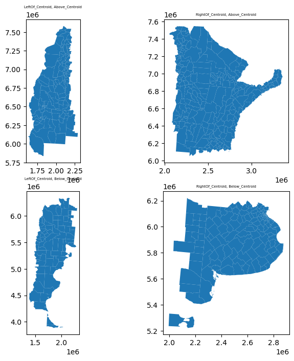

```python
fig, axs = plt.subplots(nrows=2,ncols=2,sharex=False, sharey=False,figsize=(8,8))

centroidX=centroArgentina.x[0]
centroidY=centroArgentina.y[0]

axs[0,0].set_title('LeftOf_Centroid, Above_Centroid',fontsize=5)
argentina_municipalities.cx[:centroidX,centroidY:].plot(ax=axs[0,0])

axs[0,1].set_title('RightOf_Centroid, Above_Centroid',fontsize=5)
argentina_municipalities.cx[centroidX:,centroidY:].plot(ax=axs[0,1])

axs[1,0].set_title('LeftOf_Centroid, Below_Centroid',fontsize=5)
argentina_municipalities.cx[:centroidX,:centroidY].plot(ax=axs[1,0])

axs[1,1].set_title('RightOf_Centroid, Below_Centroid',fontsize=5)
argentina_municipalities.cx[centroidX:,:centroidY].plot(ax=axs[1,1]) ;
```

```python
#profesor dijo que se puede poner con ciudades o con minucipapldfaed
```

You can create a polygon with one of these:

```python
#instead of:
argentina_municipalities.cx[:centroidX,centroidY:]#el cx es de geopandas solo lo entiende geopandas , pandas no
#el cx necesita un valor
```

|  | ADM0_ES | ADM0_PCODE | ADM1_ES | ADM1_PCODE | ADM2_ES | ADM2_REF | ADM2_PCODE | geometry |
| --- | --- | --- | --- | --- | --- | --- | --- | --- |
| 0 | Argentina | AR | La Rioja | AR046 | Arauco | Arauco | AR046007 | POLYGON Z ((2035707.200 6832436.727 0.000, 203... |
| 7 | Argentina | AR | Mendoza | AR050 | Santa Rosa | Santa Rosa | AR050112 | POLYGON Z ((1899146.694 6291175.015 0.000, 189... |
| 12 | Argentina | AR | Catamarca | AR010 | Santa María | Santa Maria | AR010091 | POLYGON Z ((2081789.023 7097206.516 0.000, 208... |
| 17 | Argentina | AR | La Rioja | AR046 | Independencia | Independencia | AR046105 | POLYGON Z ((1996043.222 6669967.019 0.000, 199... |
| 18 | Argentina | AR | La Rioja | AR046 | General Ocampo | General Ocampo | AR046084 | POLYGON Z ((2072670.364 6583469.777 0.000, 207... |
| ... | ... | ... | ... | ... | ... | ... | ... | ... |
| 509 | Argentina | AR | La Rioja | AR046 | Famatina | Famatina | AR046049 | POLYGON Z ((1907352.885 6862646.497 0.000, 190... |
| 510 | Argentina | AR | Tucumán | AR090 | Yerba Buena | Yerba Buena | AR090119 | POLYGON Z ((2154811.333 7029885.745 0.000, 215... |
| 516 | Argentina | AR | Tucumán | AR090 | La Cocha | La Cocha | AR090049 | POLYGON Z ((2137720.175 6930143.625 0.000, 213... |
| 519 | Argentina | AR | San Luis | AR074 | Junín | Junin | AR074049 | POLYGON Z ((2089223.690 6455533.587 0.000, 208... |
| 520 | Argentina | AR | Tucumán | AR090 | Juan B. Alberdi | Juan B. Alberdi | AR090042 | POLYGON Z ((2115126.424 6939897.785 0.000, 211... |

126 rows × 8 columns

### Dissolve

Let's use **dissolve**:

```python
# dissolving
argentina_municipalities.cx[:centroidX,centroidY:].dissolve()
```

|  | geometry | ADM0_ES | ADM0_PCODE | ADM1_ES | ADM1_PCODE | ADM2_ES | ADM2_REF | ADM2_PCODE |
| --- | --- | --- | --- | --- | --- | --- | --- | --- |
| 0 | POLYGON Z ((1837433.176 5990761.421 0.000, 183... | Argentina | AR | La Rioja | AR046 | Arauco | Arauco | AR046007 |

The 126 rows from the previous GDF are now one, Notice that some columns may be meaningless. And the result is:

```python
type(argentina_municipalities.cx[:centroidX,centroidY:].dissolve())
#algunas funcoines devuelven geoseries, esta devuelve un dataframe
```

```
geopandas.geodataframe.GeoDataFrame
```

As a GeoDF we can plot:

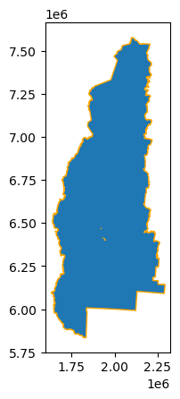

```python
argentina_municipalities.cx[:centroidX,centroidY:].dissolve().plot(edgecolor='orange')
```

By default, dissolve combines **all into one**, but dissolving **also allows combining by other column**; for example:

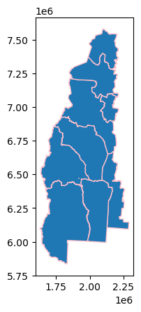

```python
# the municipalities by state
argentina_municipalities.cx[:centroidX,centroidY:].dissolve(by='ADM1_ES').plot(edgecolor='pink')
#si no le idgo nada disucleve todo y si le digo disuelve por grupos junsta todas las geometrias
#los ha juntado por estados
```

### Unary Union

This operation **is used to combine all the geometries in one GeoDF**:

```python
argentina_municipalities.cx[:centroidX,centroidY:].unary_union
```

[output not shown]

It looks like dissolve default behaviour, but:

```python
type(argentina_municipalities.cx[:centroidX,centroidY:].unary_union)
#normalenete uno hace algo para combinarlo con otras cosas
#entnces para eso necesitamos usar estrufruas conocidas
#o sea puede ser que este mapa que me arrojo se vea bien, pero mejor converetilo a una estructura concocida
#el unary union es una geometria y calcula rapido te devuleve shaping
```

```
shapely.geometry.polygon.Polygon
```

The **result** is **not a GeoDF**. It **is a *shapely* geometry**. You could **turn that into a GeoSeries**:

```python
gpd.GeoDataFrame(index=[0],
                 crs=argentina_municipalities.crs,
                 geometry=[argentina_municipalities.cx[:centroidX,centroidY:].unary_union])
#lo pongo como una lista por si hay mas geometrias
```

|  | geometry |
| --- | --- |
| 0 | POLYGON Z ((1837433.176 5990761.421 0.000, 183... |

Notice that *unary union* erase all other columns; it **only produces** the **geometry combined**.

Let me **use the dissolve this time**:

```python
# you create
Argentina_topLeft=argentina_municipalities.cx[:centroidX,centroidY:].dissolve()
# you get
Argentina_topLeft
#el disolve te devulve dataframe pero te agrag columnas q no sirven a vces
```

|  | geometry | ADM0_ES | ADM0_PCODE | ADM1_ES | ADM1_PCODE | ADM2_ES | ADM2_REF | ADM2_PCODE |
| --- | --- | --- | --- | --- | --- | --- | --- | --- |
| 0 | POLYGON Z ((1837433.176 5990761.421 0.000, 183... | Argentina | AR | La Rioja | AR046 | Arauco | Arauco | AR046007 |

Aside from the **ADM0_ES** and **geometry column**, **the rest is meaningless**, then:

```python
#por qué?
```

```python
Argentina_topLeft['zone']='NW' # add column
Argentina_topLeft=Argentina_topLeft.loc[:,['ADM0_ES','zone','geometry']]   # keep some

# result
Argentina_topLeft
```

|  | ADM0_ES | zone | geometry |
| --- | --- | --- | --- |
| 0 | Argentina | NW | POLYGON Z ((1837433.176 5990761.421 0.000, 183... |

We can **do the same with the other parts**:

```python
Argentina_topRight=argentina_municipalities.cx[centroidX:,centroidY:].dissolve()
Argentina_bottomLeft=argentina_municipalities.cx[:centroidX,:centroidY].dissolve()
Argentina_bottomRight=argentina_municipalities.cx[centroidX:,:centroidY].dissolve()

Argentina_topRight['zone']='NE'
Argentina_topRight=Argentina_topRight.loc[:,['ADM0_ES','zone','geometry']]

Argentina_bottomLeft['zone']='NE'
Argentina_bottomLeft=Argentina_bottomLeft.loc[:,['ADM0_ES','zone','geometry']]

Argentina_bottomRight['zone']='NE'
Argentina_bottomRight=Argentina_bottomRight.loc[:,['ADM0_ES','zone','geometry']]
```

Keep in mind that with **CX** you may **not get** a **perfect partition:**

```python
argentina_municipalities
```

|  | ADM0_ES | ADM0_PCODE | ADM1_ES | ADM1_PCODE | ADM2_ES | ADM2_REF | ADM2_PCODE | geometry |
| --- | --- | --- | --- | --- | --- | --- | --- | --- |
| 0 | Argentina | AR | La Rioja | AR046 | Arauco | Arauco | AR046007 | POLYGON Z ((2035707.200 6832436.727 0.000, 203... |
| 1 | Argentina | AR | Buenos Aires | AR006 | Tres Arroyos | Tres Arroyos | AR006833 | POLYGON Z ((2538302.326 5707868.076 0.000, 254... |
| 2 | Argentina | AR | Jujuy | AR038 | El Carmen | El Carmen | AR038014 | POLYGON Z ((2184906.173 7295226.281 0.000, 218... |
| 3 | Argentina | AR | Buenos Aires | AR006 | Pinamar | Pinamar | AR006644 | POLYGON Z ((2844051.406 5776077.259 0.000, 284... |
| 4 | Argentina | AR | Buenos Aires | AR006 | General Pinto | General Pinto | AR006351 | POLYGON Z ((2421316.725 6134973.446 0.000, 243... |
| ... | ... | ... | ... | ... | ... | ... | ... | ... |
| 521 | Argentina | AR | Buenos Aires | AR006 | San Pedro | San Pedro | AR006770 | POLYGON Z ((2633048.513 6217696.227 0.000, 263... |
| 522 | Argentina | AR | Salta | AR066 | Iruya | Iruya | AR066070 | POLYGON Z ((2245359.400 7485474.596 0.000, 224... |
| 523 | Argentina | AR | Jujuy | AR038 | Santa Bárbara | Santa Barbara | AR038070 | POLYGON Z ((2302696.635 7378040.184 0.000, 230... |
| 524 | Argentina | AR | Buenos Aires | AR006 | Suipacha | Suipacha | AR006784 | POLYGON Z ((2630976.901 6107554.253 0.000, 263... |
| 525 | Argentina | AR | Buenos Aires | AR006 | Salto | Salto | AR006714 | POLYGON Z ((2583841.335 6176079.272 0.000, 258... |

526 rows × 8 columns

Calculemos la diferencia:

```python
# tuple with count of rows
rowsCX=(argentina_municipalities.cx[:centroArgentina.x[0],centroArgentina.y[0]:].shape[0],\
        argentina_municipalities.cx[centroArgentina.x[0]:,centroArgentina.y[0]:].shape[0],\
        argentina_municipalities.cx[:centroArgentina.x[0],:centroArgentina.y[0]].shape[0],\
        argentina_municipalities.cx[centroArgentina.x[0]:,:centroArgentina.y[0]].shape[0])

sum(rowsCX)
#como hay cosas(municipalidades) q se repiten entonces al sumar salen menos 5753
```

```
593
```

```python
# coincidences:
len(set(argentina_municipalities.cx[:centroArgentina.x[0],centroArgentina.y[0]:].ADM2_PCODE). \
intersection(set(argentina_municipalities.cx[centroArgentina.x[0]:,centroArgentina.y[0]:].ADM2_PCODE)). \
intersection(set(argentina_municipalities.cx[:centroArgentina.x[0],:centroArgentina.y[0]].ADM2_PCODE)). \
intersection(set(argentina_municipalities.cx[centroArgentina.x[0]:,:centroArgentina.y[0]].ADM2_PCODE)))
```

```
1
```

Adding up all the rows, we have more municipalities:

```python
totalMuni=argentina_municipalities.shape[0]
totalMuni
```

```
526
```

```python
sum(rowsCX)-totalMuni
```

```
67
```

There are some that are common:

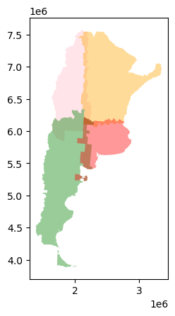

```python
base=Argentina_topLeft.plot(facecolor='pink', alpha=0.4)
Argentina_topRight.plot(ax=base,facecolor='orange', alpha=0.4)
Argentina_bottomLeft.plot(ax=base,facecolor='green', alpha=0.4)
Argentina_bottomRight.plot(ax=base,facecolor='red', alpha=0.4)
```

### Exercise 4

1. Compute the centroid of your country. 2. Combine all the polygons to the north, and also all the polygons to the south; use unary union. 3. Detect the amount of duplicates after the combination. 4. Plot both maps so that duplicates appear.

## Creating the convex hull

Some times you may have the **need to create a polygon** that **serves as an envelope to a set of points**:

```python
Argentina_museoTopLeft=museos[museos.jurisdiccion=='Municipal'].cx[:centroidX,centroidY:]
Argentina_museoTopRight=museos[museos.jurisdiccion=='Municipal'].cx[centroidX:,centroidY:]
Argentina_museoBottomLeft=museos[museos.jurisdiccion=='Municipal'].cx[:centroidX,:centroidY]
Argentina_museoBottomRight=museos[museos.jurisdiccion=='Municipal'].cx[centroidX:,:centroidY]
```

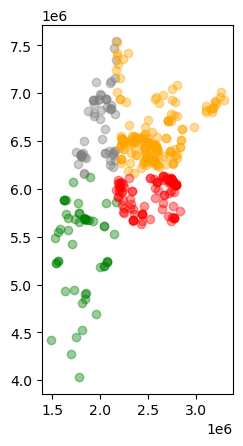

```python
base=Argentina_museoTopLeft.plot(facecolor='grey', alpha=0.4)
Argentina_museoTopRight.plot(ax=base,facecolor='orange', alpha=0.4)
Argentina_museoBottomLeft.plot(ax=base,facecolor='green', alpha=0.4)
Argentina_museoBottomRight.plot(ax=base,facecolor='red', alpha=0.4)
```

Notice we have simple points:

```python
Argentina_museoBottomLeft
```

|  | nombre | jurisdiccion | Latitud | Longitud | provincia | localidad | geometry |
| --- | --- | --- | --- | --- | --- | --- | --- |
| 215 | Museo Tecnológico De La Localidad | Municipal | -43.329400 | -65.789600 | Chubut | 28 de Julio | POINT (2003746.143 5183879.042) |
| 221 | Museo Regional Patagónico Prof. Antonio Garcés | Municipal | -45.862400 | -67.490800 | Chubut | Comodoro Rivadavia | POINT (1850151.692 4911275.483) |
| 226 | Museo De Culturas Originarias Patagónicas | Municipal | -42.903185 | -71.319191 | Chubut | Esquel | POINT (1555601.003 5249776.312) |
| 228 | Museo De Pintura Naif | Municipal | -42.915457 | -71.318485 | Chubut | Esquel | POINT (1555647.620 5248412.530) |
| 240 | Museo Municipal De Arte | Municipal | -42.768027 | -65.032037 | Chubut | Puerto Madryn | POINT (2070416.372 5241402.556) |
| 241 | Museo Regional De Rada Tilly | Municipal | -45.934138 | -67.558743 | Chubut | Rada Tilly | POINT (1844431.362 4903598.936) |
| 246 | Museo Regional Dr. Federico Escalada | Municipal | -45.698499 | -70.255966 | Chubut | Rio Mayo | POINT (1635830.046 4937911.426) |
| 247 | Museo Regional Desiderio Torres | Municipal | -45.593725 | -69.069517 | Chubut | Sarmiento | POINT (1728658.617 4946856.910) |
| 248 | Museo Municipal De Artes Visuales | Municipal | -43.249100 | -65.307400 | Chubut | Trelew | POINT (2043586.763 5189768.048) |
| 249 | Museo Pueblo De Luis | Municipal | -43.250477 | -65.310422 | Chubut | Trelew | POINT (2043328.945 5189634.740) |
| 251 | Museo Nuestras Raíces | Municipal | -43.092999 | -71.465457 | Chubut | Trevelin | POINT (1543521.402 5228775.547) |
| 252 | Museo Regional | Municipal | -43.079200 | -71.464300 | Chubut | Trevelin | POINT (1543625.394 5230307.943) |
| 258 | Museo Municipal de Arte | Municipal | -42.768661 | -65.031418 | Chubut | Puerto Madryn | POINT (2070461.178 5241327.881) |
| 259 | Museo Histórico Juan Meisen Ebene | Municipal | -42.765763 | -65.040903 | Chubut | Puerto Madryn | POINT (2069711.182 5241714.405) |
| 670 | Museo Municipal Casa Sarasola | Municipal | -37.121895 | -64.515322 | La Pampa | Quehué | POINT (2165674.225 5865600.917) |
| 687 | Parador Histórico Pulperia De Chacharramendi | Municipal | -37.334110 | -65.650778 | La Pampa | Chacharramendi | POINT (2062978.568 5849413.173) |
| 717 | Museo Municipal De Historia Natural Dr. Salvad... | Municipal | -34.983739 | -67.695712 | Mendoza | General Alvear | POINT (1893135.872 6120700.853) |
| 727 | Museo Regional De Malargüe | Municipal | -35.458679 | -69.586628 | Mendoza | Malargüe | POINT (1719097.215 6073807.012) |
| 800 | Museo Municipal, Recuerdos Del Alma | Municipal | -37.183710 | -70.669052 | Neuquén | Andacollo | POINT (1618187.172 5884237.022) |
| 801 | Museo Esteban Guerrero | Municipal | -38.352451 | -68.799999 | Neuquén | Añelo | POINT (1779747.225 5750495.545) |
| 802 | Museo De Sitio De Añelo | Municipal | -38.352451 | -68.799999 | Neuquén | Añelo | POINT (1779747.225 5750495.545) |
| 803 | Museo Y Archivo Histórico Municipal | Municipal | -38.829830 | -68.153232 | Neuquén | Centenario | POINT (1834082.524 5695315.198) |
| 807 | Museo El Minero | Municipal | -37.164552 | -70.624011 | Neuquén | Huingan-Có | POINT (1622217.846 5886306.246) |
| 808 | Museo Regional Puesto Pedro Olave | Municipal | -37.164552 | -70.624011 | Neuquén | Huingan-Có | POINT (1622217.846 5886306.246) |
| 810 | Museo Mapuche | Municipal | -39.953096 | -71.068461 | Neuquén | Junín de Los Andes | POINT (1579602.731 5577229.080) |
| 812 | Museo Histórico, Regional Y Paleontológico Emi... | Municipal | -38.531524 | -70.368931 | Neuquén | Las Lajas | POINT (1642224.973 5734206.463) |
| 815 | Museo Municipal Dr. Gregorio Álvarez | Municipal | -38.955710 | -68.062309 | Neuquén | Neuquén | POINT (1841377.348 5680996.816) |
| 816 | Museo De La Ciudad Paraje Confluencia | Municipal | -38.955262 | -68.054918 | Neuquén | Neuquén | POINT (1842020.480 5681018.809) |
| 818 | Museo Municipal Piedra Del Águila | Municipal | -40.043397 | -70.071314 | Neuquén | Piedra del Aguila | POINT (1664599.046 5565835.383) |
| 820 | Museo De La Ciudad | Municipal | -38.955601 | -68.231967 | Neuquén | Plottier | POINT (1826664.812 5681631.911) |
| 821 | Museo Municipal Argentino Urquiza | Municipal | -37.387395 | -68.925246 | Neuquén | Rincón de Los Sauces | POINT (1772328.882 5858021.788) |
| 822 | Museo Municipal Primeros Pobladores | Municipal | -40.156688 | -71.352112 | Neuquén | San Martín de Los Andes | POINT (1555199.192 5554837.403) |
| 828 | Museo Comunal Ana María Biset | Municipal | -37.136035 | -70.396904 | Neuquén | Villa Curi Leuvu | POINT (1642444.732 5889154.514) |
| 829 | Museo Municipal Ernesto Bachmann | Municipal | -39.263110 | -68.791122 | Neuquén | Villa el Chocón | POINT (1776970.225 5649340.366) |
| 830 | Museo Histórico Regional | Municipal | -40.764572 | -71.648051 | Neuquén | Villa la Angostura | POINT (1529716.435 5487477.507) |
| 832 | Museo De La Ciudad | Municipal | -38.904100 | -70.063200 | Neuquén | Zapala | POINT (1668011.098 5692324.288) |
| 834 | Casa De La Historia | Municipal | -38.938855 | -69.241336 | Neuquén | Cutral Có | POINT (1739198.294 5686629.072) |
| 837 | Archivo Historico Municipal | Municipal | -38.951917 | -68.059466 | Neuquén | Neuquen | POINT (1841642.159 5681407.464) |
| 838 | Sistema Provincial de Archivos | Municipal | -38.952134 | -68.060743 | Neuquén | Neuquen | POINT (1841530.388 5681388.163) |
| 839 | Museo Municipal De Allen | Municipal | -38.981760 | -67.827997 | Río Negro | Allen | POINT (1861565.591 5677197.563) |
| 844 | Museo Histórico Regional Alicia Zanona | Municipal | -40.105711 | -64.454549 | Río Negro | General Conesa | POINT (2143656.816 5533309.628) |
| 845 | Museo Municipal De Bellas Artes Juan Sánchez | Municipal | -39.028700 | -67.585725 | Río Negro | General Roca | POINT (1882317.152 5670991.297) |
| 847 | Museo Jorge H. Gerhold | Municipal | -41.328994 | -69.544083 | Río Negro | Ingeniero Jacobacci | POINT (1705606.341 5421944.369) |
| 848 | Museo Paleontológico De Lamarque | Municipal | -39.425503 | -65.701454 | Río Negro | Lamarque | POINT (2042549.589 5617241.572) |
| 849 | Exposición De La Historia De Los Inmigrantes C... | Municipal | -39.423634 | -65.701091 | Río Negro | Lamarque | POINT (2042595.445 5617447.124) |
| 857 | Museo Comunitario Villa Regina | Municipal | -39.094907 | -67.088747 | Río Negro | Villa Regina | POINT (1924982.546 5661423.847) |
| 948 | Museo Del Hombre Y Su Entorno | Municipal | -46.435354 | -67.521406 | Santa Cruz | Caleta Olivia | POINT (1844178.364 4847731.078) |
| 949 | Museo Regional El Calafate | Municipal | -50.339123 | -72.255631 | Santa Cruz | El Calafate | POINT (1481801.597 4423365.993) |
| 950 | Museo Histórico Y Regional Pico Truncado | Municipal | -46.802509 | -67.928467 | Santa Cruz | Pico Truncado | POINT (1810787.423 4808616.986) |
| 952 | Museo Municipal Mario Brozoski | Municipal | -47.755649 | -65.897810 | Santa Cruz | Puerto Deseado | POINT (1957440.858 4692641.400) |
| 953 | Museo Temático Nao Victoria | Municipal | -49.309623 | -67.731981 | Santa Cruz | Puerto San Julián | POINT (1810315.297 4529132.872) |
| 954 | Museo Casa De Los Pioneros | Municipal | -50.019085 | -68.524830 | Santa Cruz | Puerto Santa Cruz | POINT (1749029.755 4453205.669) |
| 959 | Museo De Los Pioneros Casa Parisi | Municipal | -51.615200 | -69.225800 | Santa Cruz | Rio Gallegos | POINT (1692138.681 4277789.007) |
| 1143 | Museo Municipal De La Ciudad De Río Grande | Municipal | -53.788000 | -67.703700 | Tierra del Fuego, Antártida e Islas del Atlánt... | Río Grande | POINT (1783082.565 4031075.811) |

**In this situation, you can not make a *convex hull***:

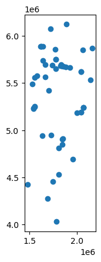

```python
Argentina_museoBottomLeft.convex_hull.plot()
```

You **first need to dissolve**, and then you **create a hull**, an **envelope of convex angles**:

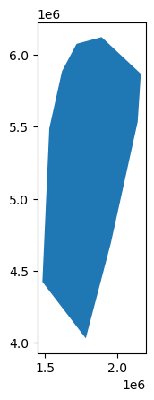

```python
Argentina_museoBottomLeft.dissolve().convex_hull.plot()
```

As we saw, the **convex hull is a polygon**:

```python
Argentina_museoBottomLeft.dissolve().convex_hull
```

```
0    POLYGON ((1783082.565 4031075.811, 1481801.597...
dtype: geometry
```

We **can make hulls from any spatial object**:

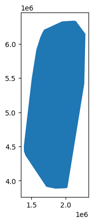

```python
# SW of Brazil as convex hull
Argentina_bottomLeft.convex_hull.plot()
```

In this last case, what if we the **polygons had not been previously combined**?

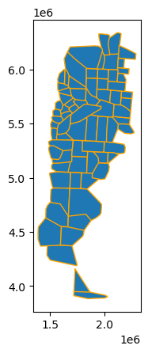

```python
argentina_municipalities.cx[:centroidX,:centroidY].convex_hull.plot(edgecolor='orange')
```

That is, you get a **convex hull** for **each geometry**.

We can also use *union* before creating a **convex hull**:

```python
# just the union
museos_nacional=museos[museos.jurisdiccion=='Nacional']
museos_nacional.unary_union
```

```python
# hull of the union
museos_nacional.unary_union.convex_hull
```

[output not shown]

Let's turn the **GS into a GDF**:

```python
museos_nacional_hull= gpd.GeoDataFrame(index=[0],
                                    crs=museos_nacional.crs,
                                    geometry=[museos_nacional.unary_union.convex_hull])
museos_nacional_hull['name']='museos nacionales hull' # optional
#por qué se le pone index [0]
# then

museos_nacional_hull
```

|  | geometry | name |
| --- | --- | --- |
| 0 | POLYGON ((1691730.796 4275392.212, 1476819.090... | museos nacionales hull |

Let's use the **GDF in plotting**:

[figure not shown]

```python
base=argentina.plot(facecolor='pink')
museos_nacional.plot(ax=base)
museos_nacional_hull.plot(ax=base,facecolor='orange',
                       edgecolor='brown',alpha=0.4,
                       hatch='X')
#como aptrapo en una geomtria ese es el convex hull, basicamente para un conjunto de coordendas encontrar lo que le envulve
#no puede dejar a nadie a fuera inclye a los que no son convex hull
#ls importancia es que nos ayuda a visulizar en donde estan la maypr cantidad e aeropuertos
```

### Exercise 5

1. Select some points from your maps. 2. Create the convex hull for those points. 3. Turn the hull into a GDF. 4. Plot the hull on top of the country.

## Spatial Overlay

We might need to create or find some geometries from the geometries we already have. Using a set theory approach, we will se the use of *intersection*, *union*, *difference*, and *symmetric difference*.

**Let me create this GeoDFs**:

```python
# the north
MunisN_argentina=argentina_municipalities.cx[:,centroidY:]
# the south
MunisS_argentina=argentina_municipalities.cx[:,:centroidY]
# the west
MunisW_argentina=argentina_municipalities.cx[:centroidX,:]
# the east
MunisE_argentina=argentina_municipalities.cx[centroidX:,:]
```

### Intersection

We keep what is common in both GeoDFs:

```python
munisMidNS_argentina=MunisN_argentina.overlay(MunisS_argentina, how="intersection",keep_geom_type=True)
munisMidNS_argentina
```

|  | ADM0_ES_1 | ADM0_PCODE_1 | ADM1_ES_1 | ADM1_PCODE_1 | ADM2_ES_1 | ADM2_REF_1 | ADM2_PCODE_1 | ADM0_ES_2 | ADM0_PCODE_2 | ADM1_ES_2 | ADM1_PCODE_2 | ADM2_ES_2 | ADM2_REF_2 | ADM2_PCODE_2 | geometry |
| --- | --- | --- | --- | --- | --- | --- | --- | --- | --- | --- | --- | --- | --- | --- | --- |
| 0 | Argentina | AR | Buenos Aires | AR006 | General Pinto | General Pinto | AR006351 | Argentina | AR | Buenos Aires | AR006 | General Pinto | General Pinto | AR006351 | POLYGON Z ((2432806.820 6120338.130 0.000, 244... |
| 1 | Argentina | AR | Buenos Aires | AR006 | Leandro N. Alem | Leandro N. Alem | AR006462 | Argentina | AR | Buenos Aires | AR006 | Leandro N. Alem | Leandro N. Alem | AR006462 | POLYGON Z ((2467305.043 6150755.672 0.000, 247... |
| 2 | Argentina | AR | Buenos Aires | AR006 | General Villegas | General Villegas | AR006392 | Argentina | AR | Buenos Aires | AR006 | General Villegas | General Villegas | AR006392 | POLYGON Z ((2390171.334 6132299.863 0.000, 238... |
| 3 | Argentina | AR | Mendoza | AR050 | San Rafael | San Rafael | AR050105 | Argentina | AR | Mendoza | AR050 | San Rafael | San Rafael | AR050105 | POLYGON Z ((1946315.712 6195039.159 0.000, 197... |
| 4 | Argentina | AR | Buenos Aires | AR006 | Rojas | Rojas | AR006686 | Argentina | AR | Buenos Aires | AR006 | Rojas | Rojas | AR006686 | POLYGON Z ((2537973.859 6186507.051 0.000, 254... |
| 5 | Argentina | AR | Buenos Aires | AR006 | Arrecifes | Arrecifes | AR006077 | Argentina | AR | Buenos Aires | AR006 | Arrecifes | Arrecifes | AR006077 | POLYGON Z ((2604110.794 6194197.834 0.000, 260... |
| 6 | Argentina | AR | Buenos Aires | AR006 | Salto | Salto | AR006714 | Argentina | AR | Buenos Aires | AR006 | Salto | Salto | AR006714 | POLYGON Z ((2583946.899 6176008.704 0.000, 258... |
| 7 | Argentina | AR | San Luis | AR074 | La Capital | La Capital | AR074056 | Argentina | AR | San Luis | AR074 | La Capital | La Capital | AR074056 | POLYGON Z ((1966259.042 6326477.172 0.000, 196... |
| 8 | Argentina | AR | San Luis | AR074 | Gobernador Dupuy | Gobernador Dupuy | AR074042 | Argentina | AR | San Luis | AR074 | Gobernador Dupuy | Gobernador Dupuy | AR074042 | POLYGON Z ((2130453.141 6129423.650 0.000, 213... |
| 9 | Argentina | AR | Mendoza | AR050 | General Alvear | General Alvear | AR050014 | Argentina | AR | Mendoza | AR050 | General Alvear | General Alvear | AR050014 | POLYGON Z ((1977047.915 6171334.337 0.000, 197... |
| 10 | Argentina | AR | San Luis | AR074 | General Pedernera | General Pedernera | AR074035 | Argentina | AR | San Luis | AR074 | General Pedernera | General Pedernera | AR074035 | POLYGON Z ((2136583.551 6337094.458 0.000, 213... |
| 11 | Argentina | AR | Córdoba | AR014 | General Roca | General Roca | AR014035 | Argentina | AR | Córdoba | AR014 | General Roca | General Roca | AR014035 | POLYGON Z ((2137386.201 6221700.852 0.000, 213... |
| 12 | Argentina | AR | San Luis | AR074 | Gobernador Dupuy | Gobernador Dupuy | AR074042 | Argentina | AR | La Pampa | AR042 | Loventué | Loventue | AR042098 | POLYGON Z ((2107621.744 5995430.502 0.000, 211... |
| 13 | Argentina | AR | Buenos Aires | AR006 | San Antonio de Areco | San Antonio de Areco | AR006735 | Argentina | AR | Buenos Aires | AR006 | San Antonio de Areco | San Antonio de Areco | AR006735 | POLYGON Z ((2674938.057 6165302.727 0.000, 267... |
| 14 | Argentina | AR | Buenos Aires | AR006 | Carmen de Areco | Carmen de Areco | AR006161 | Argentina | AR | Buenos Aires | AR006 | Carmen de Areco | Carmen de Areco | AR006161 | POLYGON Z ((2631935.525 6142320.435 0.000, 263... |
| 15 | Argentina | AR | Buenos Aires | AR006 | Exaltación de la Cruz | Exaltacion de la Cruz | AR006266 | Argentina | AR | Buenos Aires | AR006 | Exaltación de la Cruz | Exaltacion de la Cruz | AR006266 | POLYGON Z ((2680305.321 6144675.141 0.000, 268... |
| 16 | Argentina | AR | Buenos Aires | AR006 | Capitán Sarmiento | Capitan Sarmiento | AR006140 | Argentina | AR | Buenos Aires | AR006 | Capitán Sarmiento | Capitan Sarmiento | AR006140 | POLYGON Z ((2635287.950 6170031.420 0.000, 263... |
| 17 | Argentina | AR | Buenos Aires | AR006 | Zárate | Zarate | AR006882 | Argentina | AR | Buenos Aires | AR006 | Zárate | Zarate | AR006882 | POLYGON Z ((2692460.928 6182695.125 0.000, 269... |
| 18 | Argentina | AR | Buenos Aires | AR006 | San Fernando | San Fernando | AR006749 | Argentina | AR | Buenos Aires | AR006 | San Fernando | San Fernando | AR006749 | MULTIPOLYGON Z (((2771419.010 6128482.989 0.00... |
| 19 | Argentina | AR | Buenos Aires | AR006 | Campana | Campana | AR006126 | Argentina | AR | Buenos Aires | AR006 | Campana | Campana | AR006126 | POLYGON Z ((2729057.018 6162808.568 0.000, 272... |
| 20 | Argentina | AR | Buenos Aires | AR006 | General Arenales | General Arenales | AR006294 | Argentina | AR | Buenos Aires | AR006 | General Arenales | General Arenales | AR006294 | POLYGON Z ((2497533.777 6171299.739 0.000, 249... |
| 21 | Argentina | AR | Buenos Aires | AR006 | Junín | Junin | AR006413 | Argentina | AR | Buenos Aires | AR006 | Junín | Junin | AR006413 | POLYGON Z ((2518592.521 6145306.208 0.000, 251... |
| 22 | Argentina | AR | Mendoza | AR050 | Malargüe | Malargue | AR050077 | Argentina | AR | Mendoza | AR050 | Malargüe | Malargue | AR050077 | POLYGON Z ((1662772.839 6160409.950 0.000, 166... |

This is similar to a *spatial join*:

```python
MunisN_argentina.sjoin(MunisS_argentina, how="inner", predicate='contains')
```

|  | ADM0_ES_left | ADM0_PCODE_left | ADM1_ES_left | ADM1_PCODE_left | ADM2_ES_left | ADM2_REF_left | ADM2_PCODE_left | geometry | index_right | ADM0_ES_right | ADM0_PCODE_right | ADM1_ES_right | ADM1_PCODE_right | ADM2_ES_right | ADM2_REF_right | ADM2_PCODE_right |
| --- | --- | --- | --- | --- | --- | --- | --- | --- | --- | --- | --- | --- | --- | --- | --- | --- |
| 4 | Argentina | AR | Buenos Aires | AR006 | General Pinto | General Pinto | AR006351 | POLYGON Z ((2421316.725 6134973.446 0.000, 243... | 4 | Argentina | AR | Buenos Aires | AR006 | General Pinto | General Pinto | AR006351 |
| 30 | Argentina | AR | San Luis | AR074 | Gobernador Dupuy | Gobernador Dupuy | AR074042 | POLYGON Z ((2131370.565 6142762.326 0.000, 213... | 30 | Argentina | AR | San Luis | AR074 | Gobernador Dupuy | Gobernador Dupuy | AR074042 |
| 37 | Argentina | AR | Buenos Aires | AR006 | San Antonio de Areco | San Antonio de Areco | AR006735 | POLYGON Z ((2674911.340 6165337.318 0.000, 267... | 37 | Argentina | AR | Buenos Aires | AR006 | San Antonio de Areco | San Antonio de Areco | AR006735 |
| 57 | Argentina | AR | Buenos Aires | AR006 | Rojas | Rojas | AR006686 | POLYGON Z ((2537409.340 6186011.722 0.000, 253... | 57 | Argentina | AR | Buenos Aires | AR006 | Rojas | Rojas | AR006686 |
| 125 | Argentina | AR | Buenos Aires | AR006 | Carmen de Areco | Carmen de Areco | AR006161 | POLYGON Z ((2631524.583 6142783.347 0.000, 263... | 125 | Argentina | AR | Buenos Aires | AR006 | Carmen de Areco | Carmen de Areco | AR006161 |
| 141 | Argentina | AR | Buenos Aires | AR006 | General Arenales | General Arenales | AR006294 | POLYGON Z ((2489705.595 6180887.889 0.000, 249... | 141 | Argentina | AR | Buenos Aires | AR006 | General Arenales | General Arenales | AR006294 |
| 158 | Argentina | AR | Buenos Aires | AR006 | Arrecifes | Arrecifes | AR006077 | POLYGON Z ((2602745.233 6197389.003 0.000, 260... | 158 | Argentina | AR | Buenos Aires | AR006 | Arrecifes | Arrecifes | AR006077 |
| 190 | Argentina | AR | San Luis | AR074 | La Capital | La Capital | AR074056 | POLYGON Z ((1965607.211 6326537.210 0.000, 196... | 190 | Argentina | AR | San Luis | AR074 | La Capital | La Capital | AR074056 |
| 228 | Argentina | AR | Buenos Aires | AR006 | San Fernando | San Fernando | AR006749 | MULTIPOLYGON Z (((2758179.827 6153566.452 0.00... | 228 | Argentina | AR | Buenos Aires | AR006 | San Fernando | San Fernando | AR006749 |
| 240 | Argentina | AR | Mendoza | AR050 | General Alvear | General Alvear | AR050014 | POLYGON Z ((1976792.576 6171691.654 0.000, 197... | 240 | Argentina | AR | Mendoza | AR050 | General Alvear | General Alvear | AR050014 |
| 244 | Argentina | AR | Mendoza | AR050 | Malargüe | Malargue | AR050077 | POLYGON Z ((1662461.766 6160499.265 0.000, 166... | 244 | Argentina | AR | Mendoza | AR050 | Malargüe | Malargue | AR050077 |
| 284 | Argentina | AR | Buenos Aires | AR006 | Leandro N. Alem | Leandro N. Alem | AR006462 | POLYGON Z ((2464029.169 6154793.295 0.000, 246... | 284 | Argentina | AR | Buenos Aires | AR006 | Leandro N. Alem | Leandro N. Alem | AR006462 |
| 315 | Argentina | AR | Mendoza | AR050 | San Rafael | San Rafael | AR050105 | POLYGON Z ((1947637.085 6215607.207 0.000, 194... | 315 | Argentina | AR | Mendoza | AR050 | San Rafael | San Rafael | AR050105 |
| 341 | Argentina | AR | Buenos Aires | AR006 | Exaltación de la Cruz | Exaltacion de la Cruz | AR006266 | POLYGON Z ((2678092.526 6145359.498 0.000, 268... | 341 | Argentina | AR | Buenos Aires | AR006 | Exaltación de la Cruz | Exaltacion de la Cruz | AR006266 |
| 367 | Argentina | AR | San Luis | AR074 | General Pedernera | General Pedernera | AR074035 | POLYGON Z ((2134297.185 6337790.189 0.000, 213... | 367 | Argentina | AR | San Luis | AR074 | General Pedernera | General Pedernera | AR074035 |
| 378 | Argentina | AR | Buenos Aires | AR006 | Junín | Junin | AR006413 | POLYGON Z ((2517451.075 6144290.554 0.000, 251... | 378 | Argentina | AR | Buenos Aires | AR006 | Junín | Junin | AR006413 |
| 384 | Argentina | AR | Córdoba | AR014 | General Roca | General Roca | AR014035 | POLYGON Z ((2137345.277 6221729.068 0.000, 213... | 384 | Argentina | AR | Córdoba | AR014 | General Roca | General Roca | AR014035 |
| 415 | Argentina | AR | Buenos Aires | AR006 | Campana | Campana | AR006126 | POLYGON Z ((2728896.734 6163113.949 0.000, 272... | 415 | Argentina | AR | Buenos Aires | AR006 | Campana | Campana | AR006126 |
| 416 | Argentina | AR | Buenos Aires | AR006 | General Villegas | General Villegas | AR006392 | POLYGON Z ((2391366.168 6136067.567 0.000, 239... | 416 | Argentina | AR | Buenos Aires | AR006 | General Villegas | General Villegas | AR006392 |
| 494 | Argentina | AR | Buenos Aires | AR006 | Capitán Sarmiento | Capitan Sarmiento | AR006140 | POLYGON Z ((2635290.046 6170057.581 0.000, 263... | 494 | Argentina | AR | Buenos Aires | AR006 | Capitán Sarmiento | Capitan Sarmiento | AR006140 |
| 504 | Argentina | AR | Buenos Aires | AR006 | Zárate | Zarate | AR006882 | POLYGON Z ((2692079.637 6183856.461 0.000, 269... | 504 | Argentina | AR | Buenos Aires | AR006 | Zárate | Zarate | AR006882 |
| 525 | Argentina | AR | Buenos Aires | AR006 | Salto | Salto | AR006714 | POLYGON Z ((2583841.335 6176079.272 0.000, 258... | 525 | Argentina | AR | Buenos Aires | AR006 | Salto | Salto | AR006714 |

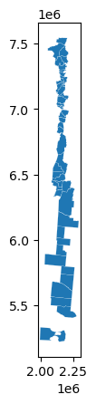

```python
# keeping the overlay
munisMidWE_argentina=MunisW_argentina.overlay(MunisE_argentina, how="intersection",keep_geom_type=True)
munisMidWE_argentina.plot(edgecolor='white',linewidth=0.1)
```

### Union

Let me unite the previous two GeoDFs. First, take a look at each one:

```python
munisMidNS_argentina.info()
```

```
<class 'geopandas.geodataframe.GeoDataFrame'>
RangeIndex: 23 entries, 0 to 22
Data columns (total 15 columns):
 #   Column        Non-Null Count  Dtype
---  ------        --------------  -----
 0   ADM0_ES_1     23 non-null     object
 1   ADM0_PCODE_1  23 non-null     object
 2   ADM1_ES_1     23 non-null     object
 3   ADM1_PCODE_1  23 non-null     object
 4   ADM2_ES_1     23 non-null     object
 5   ADM2_REF_1    23 non-null     object
 6   ADM2_PCODE_1  23 non-null     object
 7   ADM0_ES_2     23 non-null     object
 8   ADM0_PCODE_2  23 non-null     object
 9   ADM1_ES_2     23 non-null     object
 10  ADM1_PCODE_2  23 non-null     object
 11  ADM2_ES_2     23 non-null     object
 12  ADM2_REF_2    23 non-null     object
 13  ADM2_PCODE_2  23 non-null     object
 14  geometry      23 non-null     geometry
dtypes: geometry(1), object(14)
memory usage: 2.8+ KB
```

```python
munisMidWE_argentina.info()
```

```
<class 'geopandas.geodataframe.GeoDataFrame'>
RangeIndex: 45 entries, 0 to 44
Data columns (total 15 columns):
 #   Column        Non-Null Count  Dtype
---  ------        --------------  -----
 0   ADM0_ES_1     45 non-null     object
 1   ADM0_PCODE_1  45 non-null     object
 2   ADM1_ES_1     45 non-null     object
 3   ADM1_PCODE_1  45 non-null     object
 4   ADM2_ES_1     45 non-null     object
 5   ADM2_REF_1    45 non-null     object
 6   ADM2_PCODE_1  45 non-null     object
 7   ADM0_ES_2     45 non-null     object
 8   ADM0_PCODE_2  45 non-null     object
 9   ADM1_ES_2     45 non-null     object
 10  ADM1_PCODE_2  45 non-null     object
 11  ADM2_ES_2     45 non-null     object
 12  ADM2_REF_2    45 non-null     object
 13  ADM2_PCODE_2  45 non-null     object
 14  geometry      45 non-null     geometry
dtypes: geometry(1), object(14)
memory usage: 5.4+ KB
```

The **overlay combines the geometries**, but **not** the **attributes**. **Let me subset and show you**:

```python
keep=['ADM0_ES_1','ADM1_ES_1','ADM2_ES_1','geometry']
munisMidNS_argentina=munisMidNS_argentina.loc[:,keep]
munisMidWE_argentina=munisMidWE_argentina.loc[:,keep]
```

```python
# now
munisMidNS_argentina.overlay(munisMidWE_argentina,how="union",keep_geom_type=True)
#creo otracolumna ha duplicado pero el union solo trabaja con geometrias
```

|  | ADM0_ES_1_1 | ADM1_ES_1_1 | ADM2_ES_1_1 | ADM0_ES_1_2 | ADM1_ES_1_2 | ADM2_ES_1_2 | geometry |
| --- | --- | --- | --- | --- | --- | --- | --- |
| 0 | Argentina | Córdoba | General Roca | Argentina | Córdoba | General Roca | POLYGON Z ((2137474.958 6221703.567 0.000, 213... |
| 1 | Argentina | Buenos Aires | General Pinto | NaN | NaN | NaN | POLYGON Z ((2432806.820 6120338.130 0.000, 244... |
| 2 | Argentina | Buenos Aires | Leandro N. Alem | NaN | NaN | NaN | POLYGON Z ((2467305.043 6150755.672 0.000, 247... |
| 3 | Argentina | Buenos Aires | General Villegas | NaN | NaN | NaN | POLYGON Z ((2389318.632 6132402.140 0.000, 238... |
| 4 | Argentina | Mendoza | San Rafael | NaN | NaN | NaN | POLYGON Z ((1946315.712 6195039.159 0.000, 197... |
| ... | ... | ... | ... | ... | ... | ... | ... |
| 62 | NaN | NaN | NaN | Argentina | Tucumán | Trancas | POLYGON Z ((2165498.999 7101539.224 0.000, 216... |
| 63 | NaN | NaN | NaN | Argentina | Tucumán | Leales | POLYGON Z ((2167201.153 7004641.461 0.000, 216... |
| 64 | NaN | NaN | NaN | Argentina | Salta | La Candelaria | POLYGON Z ((2173252.299 7123203.718 0.000, 217... |
| 65 | NaN | NaN | NaN | Argentina | Tucumán | Yerba Buena | POLYGON Z ((2154819.403 7029883.139 0.000, 215... |
| 66 | NaN | NaN | NaN | Argentina | Jujuy | Yaví | POLYGON Z ((2140580.380 7546712.579 0.000, 214... |

67 rows × 7 columns

As you see, geometries are fine, but not attributes. It is strictly NOT appending the GeoDFs:

```python
# appending
pd.concat([munisMidNS_argentina,munisMidWE_argentina],ignore_index=True)
```

|  | ADM0_ES_1 | ADM1_ES_1 | ADM2_ES_1 | geometry |
| --- | --- | --- | --- | --- |
| 0 | Argentina | Buenos Aires | General Pinto | POLYGON Z ((2432806.820 6120338.130 0.000, 244... |
| 1 | Argentina | Buenos Aires | Leandro N. Alem | POLYGON Z ((2467305.043 6150755.672 0.000, 247... |
| 2 | Argentina | Buenos Aires | General Villegas | POLYGON Z ((2390171.334 6132299.863 0.000, 238... |
| 3 | Argentina | Mendoza | San Rafael | POLYGON Z ((1946315.712 6195039.159 0.000, 197... |
| 4 | Argentina | Buenos Aires | Rojas | POLYGON Z ((2537973.859 6186507.051 0.000, 254... |
| ... | ... | ... | ... | ... |
| 63 | Argentina | Tucumán | Trancas | POLYGON Z ((2165498.999 7101539.224 0.000, 216... |
| 64 | Argentina | Tucumán | Leales | POLYGON Z ((2167201.153 7004641.461 0.000, 216... |
| 65 | Argentina | Salta | La Candelaria | POLYGON Z ((2173252.299 7123203.718 0.000, 217... |
| 66 | Argentina | Tucumán | Yerba Buena | POLYGON Z ((2154819.403 7029883.139 0.000, 215... |
| 67 | Argentina | Jujuy | Yaví | POLYGON Z ((2140580.380 7546712.579 0.000, 214... |

68 rows × 4 columns

**You will append if** you are **interested in the keeping the attributes**. But you **just do the overlay if** you are **planing to combine final results**:

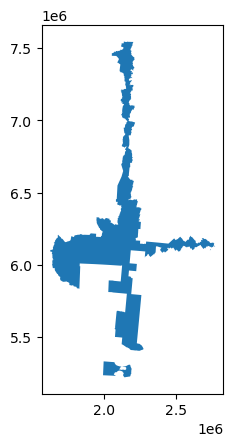

```python
munisMidNS_argentina.dissolve().overlay(munisMidWE_argentina.dissolve(), how="union",keep_geom_type=True).dissolve().plot()
```

**Let me create an object to save the previous result**:

```python
muniMidArgentina=munisMidNS_argentina.dissolve().overlay(munisMidWE_argentina.dissolve(), how="union",keep_geom_type=True).dissolve()
muniMidArgentina
```

|  | geometry | ADM0_ES_1_1 | ADM1_ES_1_1 | ADM2_ES_1_1 | ADM0_ES_1_2 | ADM1_ES_1_2 | ADM2_ES_1_2 |
| --- | --- | --- | --- | --- | --- | --- | --- |
| 0 | MULTIPOLYGON Z (((2116097.038 5276673.150 0.00... | Argentina | Buenos Aires | General Pinto | Argentina | Córdoba | Pocho |

```python
# some cleaning

muniMidArgentina['zone']='middles'
muniMidArgentina=muniMidArgentina.loc[:,['ADM0_ES_1_1','zone','geometry']]
muniMidArgentina
```

|  | ADM0_ES_1_1 | zone | geometry |
| --- | --- | --- | --- |
| 0 | Argentina | middles | MULTIPOLYGON Z (((2116097.038 5276673.150 0.00... |

### Difference

Here, you **keep what belongs to the GeoDF** to left that **is not in the GeoDF to the right**:

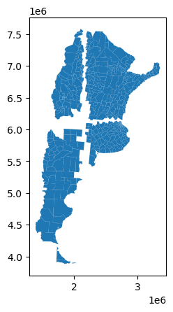

```python
# with the municipalities
argentina_municipalities.overlay(muniMidArgentina, how='difference').plot()
```

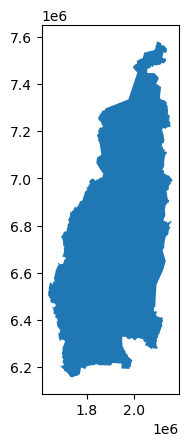

```python
# with the zones
Argentina_topLeft.overlay(muniMidArgentina, how='difference').plot()
```

### Symmetric Difference

This is the opposite to *intersection*, you keep what is not in the intersection:

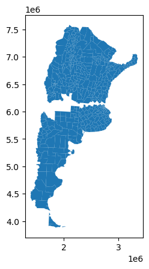

```python
MunisN_argentina.overlay(MunisS_argentina, how="symmetric_difference",keep_geom_type=False).plot()
```

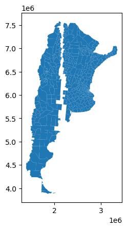

```python
MunisW_argentina.overlay(MunisE_argentina, how="symmetric_difference",keep_geom_type=False).plot()
```

### Exercise 6

1. Apply two of these operations to your maps. 2. Apply two of these operations to the next maps:

```python
# hulls para los museos municipales:
Argentina_museoTopLeft_hull=Argentina_museoTopLeft.dissolve().convex_hull
Argentina_museoTopRight_hull=Argentina_museoTopRight.dissolve().convex_hull
Argentina_museoBottomLeft_hull=Argentina_museoBottomLeft.dissolve().convex_hull
Argentina_museoBottomRight_hull=Argentina_museoBottomRight.dissolve().convex_hull
```

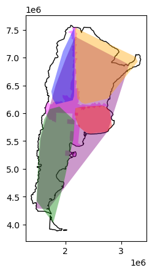

```python
base = argentina.plot(color='white', edgecolor='black') #unprojected
muniMidArgentina.plot(ax=base,facecolor='magenta',alpha=0.4) #unprojected
museos_nacional_hull.plot(ax=base,facecolor='purple',alpha=0.4)
Argentina_museoTopLeft_hull.plot(ax=base,facecolor='blue', alpha=0.4)
Argentina_museoTopRight_hull.plot(ax=base,facecolor='orange', alpha=0.4)
Argentina_museoBottomLeft_hull.plot(ax=base,facecolor='green', alpha=0.4)
Argentina_museoBottomRight_hull.plot(ax=base,facecolor='red', alpha=0.4)
```

```python
#convirtiendo a gdf
```

```python
Argentina_museoTopLeft_hull= gpd.GeoDataFrame(index=[0],
                                    crs=museos_nacional.crs,
                                    geometry=[Argentina_museoTopLeft.unary_union.convex_hull])

Argentina_museoTopRight_hull= gpd.GeoDataFrame(index=[0],
                                    crs=museos_nacional.crs,
                                    geometry=[Argentina_museoTopRight.unary_union.convex_hull])

Argentina_museoBottomLeft_hull= gpd.GeoDataFrame(index=[0],
                                    crs=museos_nacional.crs,
                                    geometry=[Argentina_museoBottomLeft.unary_union.convex_hull])

Argentina_museoBottomRight_hull= gpd.GeoDataFrame(index=[0],
                                    crs=museos_nacional.crs,
                                    geometry=[Argentina_museoBottomRight.unary_union.convex_hull])
```

```python
#muniMidArgentina=munisMidNS_argentina.dissolve().overlay(munisMidWE_argentina.dissolve(), how="union",keep_geom_type=True).dissolve()
#muniMidArgentina
```

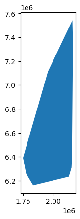

```python
Argentina_museoTopLeft_hull.overlay(Argentina_museoTopRight_hull, how='difference').plot()
```

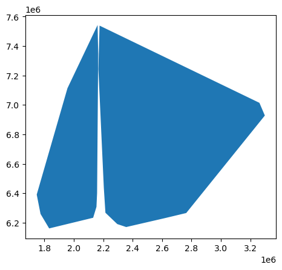

```python
Argentina_museoTopLeft_hull.overlay(Argentina_museoTopRight_hull, how='union').plot()
```

## Validity of Geometry

Geometries are created in a way that **some issues may appear, especially in (multi) polygons**. Let's check if our recent maps on states and municipalities are valid:

```python
# non valid
argentina_municipalities[~argentina_municipalities.is_valid]
```

|  | ADM0_ES | ADM0_PCODE | ADM1_ES | ADM1_PCODE | ADM2_ES | ADM2_REF | ADM2_PCODE | geometry |
| --- | --- | --- | --- | --- | --- | --- | --- | --- |

```
C:\Users\Edgar Ramos Castro\AppData\Local\Temp\ipykernel_18388\1367255169.py:2: UserWarning: The GeoDataFrame you are attempting to plot is empty. Nothing has been displayed.
  argentina_municipalities[~argentina_municipalities.is_valid].plot()
```

[figure not shown]

```python
# see the invalid:
argentina_municipalities[~argentina_municipalities.is_valid].plot()
```

```python
# what is wrong?

from shapely.validation import explain_validity, make_valid

explain_validity(argentina_municipalities[~argentina_municipalities.is_valid].geometry)
```

```
GeoSeries([], Name: geometry, dtype: geometry)
```

```python
# varieties?
argentina_municipalities['validity']=[x.split('[')[0] for x in argentina_municipalities.geometry.apply(lambda x: explain_validity(x))]
argentina_municipalities['validity'].value_counts()
```

```
validity
Valid Geometry    526
Name: count, dtype: int64
```

```python
# solving the issue:
argentina_municipalities.drop(columns=['validity'],inplace=True)

argentina_municipalities_valid=argentina_municipalities.copy()

argentina_municipalities_valid['geometry'] = [make_valid(row)  if not row.is_valid else row for row in argentina_municipalities_valid['geometry'] ]
#any invalid?
argentina_municipalities_valid[~argentina_municipalities_valid.is_valid]
```

|  | ADM0_ES | ADM0_PCODE | ADM1_ES | ADM1_PCODE | ADM2_ES | ADM2_REF | ADM2_PCODE | geometry |
| --- | --- | --- | --- | --- | --- | --- | --- | --- |

```python
[x for x in argentina_municipalities_valid["geometry"]]
```

[output not shown]

[output cut: 471 more lines]

[output not shown]

```python
pd.Series([type(x) for x in argentina_municipalities_valid.geometry]).value_counts()
```

```
<class 'shapely.geometry.polygon.Polygon'>              507
<class 'shapely.geometry.multipolygon.MultiPolygon'>     19
Name: count, dtype: int64
```

```python
# brazil.to_file(os.path.join("maps","brazilMaps_5641_all.gpkg"),layer='country', driver="GPKG")
# brazil_cities.to_file(os.path.join("maps","brazilMaps_5641_all.gpkg"),layer='cities', driver="GPKG")
# brazil_rivers.to_file(os.path.join("maps","brazilMaps_5641_all.gpkg"),layer='rivers', driver="GPKG")
# airports.to_file(os.path.join("maps","brazilMaps_5641_all.gpkg"),layer='airports', driver="GPKG")
# brazil_border.to_file(os.path.join("maps","brazilMaps_5641_all.gpkg"), layer='border', driver="GPKG")
# brazil_states.to_file(os.path.join("maps","brazilMaps_5641_all.gpkg"), layer='states', driver="GPKG")
# brazil_municipalities.to_file(os.path.join("maps","brazilMaps_5641_all.gpkg"), layer='municipalities', driver="GPKG")
```